# Assignment 08

## Try to submit the assignment as an html file

### Print your Emory code below

```python
# Write your answer here
2575182
```

### Import the pandas, numpy, and matplotlib.pyplot libraries

```python
# Write your answer here
import pandas as pd
import numpy as np
import matplotlib.pyplot as plt
```

### This script creates a DataFrame with driver data for questions (a)-(d). Please execute the code and check the DataFrame.

```python
# Create the homework_data DataFrame
homework_data = pd.DataFrame({
    'driver_id': [1, 2, 3, 4, 5, 6, 7, 8, 9, 10],
    'driver_name': [
        'Simon Cowell', 'Fernando Alonso', 'Heinrich Bach',
        'Giorgio Soprano', 'Lewis Hamilton', 'Henry Louvre',
        'Sebastian Vettel', 'Lukas Zech', 'Donic Kovak',
        'Michael Holzmieter'
    ],
    'nationality': [
        'British', 'Spanish', 'German', 'Spanish', 'British',
        'British', 'German', 'German', 'German', 'German'
    ],
    'lap_times': [74, 26, 82, 87, 103, 32, 91, 53, 11, 24]
})

# Display the DataFrame to verify entries
print(homework_data)
```

```
   driver_id         driver_name nationality  lap_times
0          1        Simon Cowell     British         74
1          2     Fernando Alonso     Spanish         26
2          3       Heinrich Bach      German         82
3          4     Giorgio Soprano     Spanish         87
4          5      Lewis Hamilton     British        103
5          6        Henry Louvre     British         32
6          7    Sebastian Vettel      German         91
7          8          Lukas Zech      German         53
8          9         Donic Kovak      German         11
9         10  Michael Holzmieter      German         24
```

(a) Subset and Sort

```python
# Write your answer here
homework_data.query('nationality == "British"')
datasorted = homework_data.sort_values(by = "driver_name", ascending = True)
display(datasorted)
```

|  | driver_id | driver_name | nationality | lap_times |
| --- | --- | --- | --- | --- |
| 8 | 9 | Donic Kovak | German | 11 |
| 1 | 2 | Fernando Alonso | Spanish | 26 |
| 3 | 4 | Giorgio Soprano | Spanish | 87 |
| 2 | 3 | Heinrich Bach | German | 82 |
| 5 | 6 | Henry Louvre | British | 32 |
| 4 | 5 | Lewis Hamilton | British | 103 |
| 7 | 8 | Lukas Zech | German | 53 |
| 9 | 10 | Michael Holzmieter | German | 24 |
| 6 | 7 | Sebastian Vettel | German | 91 |
| 0 | 1 | Simon Cowell | British | 74 |

(b) Count Unique Values

- Count the number of unique nationalities in the dataset using `nunique`.
- Count the total number of rows in the dataset using `shape`.
- Assign clear variable names to these counts.

```python
# Write your answer here
unique_nationalities_count = homework_data['nationality'].nunique()
total_row_count = homework_data.shape[0]

print("Nationalities:", unique_nationalities_count)
print("Rows:", total_row_count)
```

```
Nationalities: 3
Rows: 10
```

(c) Groupby and Aggregate

- Calculate the average of `lap_times` grouped by `driver_id` using `groupby` and `agg`.
- Reset the index of the resulting DataFrame.
- Sort the results by the average `lap_times`.

```python
# Write your answer here
average_lap_times = homework_data.groupby('driver_id').agg({'lap_times': 'mean'})
average_lap_times = average_lap_times.reset_index()
average_lap_times_sorted = average_lap_times.sort_values(by='lap_times')

print(average_lap_times_sorted)
```

```
   driver_id  lap_times
8          9       11.0
9         10       24.0
1          2       26.0
5          6       32.0
7          8       53.0
0          1       74.0
2          3       82.0
3          4       87.0
6          7       91.0
4          5      103.0
```

(d) Groupby, Aggregate, and Filter

- Calculate the sum of `lap_times` grouped by `nationality` using `groupby` and `agg`.
- Filter nationalities with a sum of `lap_times` strictly higher than 150 using `query`.

```python
# Write your answer here
nationality_lap_times = homework_data.groupby('nationality').agg({'lap_times': 'sum'})
nationality_lap_times = nationality_lap_times.reset_index()
nationality_lap_times_filtered = nationality_lap_times.query('lap_times > 150')

print(nationality_lap_times_filtered)
```

```
  nationality  lap_times
0     British        209
1      German        261
```

(e) Plot

- Plot the average `lap_times` grouped by `driver_id` using `plot` and `kind='bar'`.
- Set the title of the plot to '`Average Lap Times by Driver ID`'.
- Set the x-axis label to '`Driver ID`'.
- Set the y-axis label to '`Average Lap Time`'.

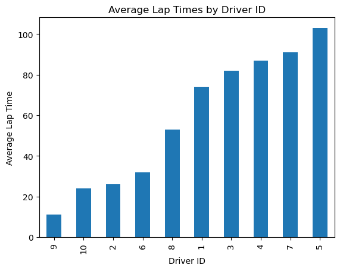

```python
# Write your answer here
average_lap_times = homework_data.groupby('driver_id').agg({'lap_times': 'mean'}).reset_index()
average_lap_times_sorted = average_lap_times.sort_values(by='lap_times')

average_lap_times_sorted.plot(
    x='driver_id',
    y='lap_times',
    kind='bar',
    title='Average Lap Times by Driver ID',
    xlabel='Driver ID',
    ylabel='Average Lap Time',
    legend=False
)

plt.show()
```